# Food Insecurity in Oregon 2020

A case study in factors that affect food insecurity

Westley Winks

11/21/2021

# Step 1: Ask

- What is the food insecurity rate in Oregon in 2020?
- What types of households are most food insecure in Oregon?
- Where are food insecure people in Oregon?
- What is a general profile for a food insecure person in Oregon?

# Step 2: Prepare

Where is data coming from?  
- CPS, Current Population Survey

Factors to be used will include:

### VARIABLES

- HUFINAL = Final outcome of interview
- HRYEAR4 = Year of interview
- HRFS12M1 = Food insecurity status, last 12 months (1 is food secure, 2 and 3 are food insecure, negative numbers mean no useful - response)
- HRFS30D1 = Food insecurity status, last 30 days (1 is food secure, 2 and 3 are food insecure, negative numbers mean no useful response)
- GESTFIPS = Geographic FIPS code (Oregon is 41)
- HRPOOR = Above or below 185% poverty (1 is below, 2 is above or income not reported), recoded from family income
- HRNUMHOU = Household members
- HRHTYPE = Household type
- GTMETSTA = Metro status (1 is metropolitan, 2 is non-metropolitan, 3 is no response)
- PEMARITL = Marital status
- PESEX = Sex (1 is male, 2 is female, non-binary not represented)
- PEAFEVER = Did you serve active duty? (1 is yes, 2 is no)
- PEEDUCA = Highest level of school completed
- PTDTRACE = Race
- PRCITSHP = Citizenship status
- PEMJOT = Do you have more than one job?
- PEHRUSLT = How many hours per week do you work each week?
- HRSUPINT = Whether or not they were interviewed for food security supplement survey (1 for yes, 2 for no)
- PRTAGE = Age

# Step 3: Process

In the full dataset for 2020, there are 132,036 observations across 507 variables. There are major entities (ERS, USDA) that use all of this data to get important stats and summaries of the nation. For simplicity, I only want to pull out specific ones that will help answer the business task described above. The selected variables are listed above. I am also choosing to just look at responses from Oregon. I also want to put in more meaningful variable names and definitions.

```r
library(tidyverse)
library(janitor)
```

```r
df <- read.csv("dec20pub.csv") %>%
  select(HUFINAL, HRFS12M1, HRFS30D1, GESTFIPS, HRPOOR, HRNUMHOU, HRHTYPE,
         GTMETSTA, PEMARITL, PESEX, PEAFEVER, PEEDUCA, PEMLR, PTDTRACE,
         PRCITSHP, PEMJOT, PEHRUSLT, PRNMCHLD, HRSUPINT, PRTAGE) %>%
  filter(GESTFIPS == 41) %>% # in Oregon
  filter(HRSUPINT == 1) %>% # interviewed for food security
  filter(HUFINAL %in% c(1, 201)) # fully completed survey
```

```r
df_2 <- df %>%
  mutate(food_insec_12mo = case_when(
    HRFS12M1 == 1 ~ "Food Secure",
    HRFS12M1 %in% 2:3 ~ "Food Insecure",
    HRFS12M1 == -9 ~ "No Response"
  )) %>%
  mutate(food_insec_30d = case_when(
    HRFS30D1 == 1 ~ "Food Secure",
    HRFS30D1 %in% 2:3 ~ "Food Insecure",
    HRFS30D1 == -9 ~ "No Response"
  )) %>%
  mutate(pov_level = case_when(
    HRPOOR == 1 ~ "Below 185% Poverty",
    HRPOOR == 2 ~ "Above 185% Poverty or Income Not Reported"
  )) %>%
  mutate(num_in_house = HRNUMHOU) %>%
  mutate(house_type = case_when(
    HRHTYPE == 0 ~ "Non-Interview",
    HRHTYPE == 1 ~ "Husband Wife Primary Family",
    HRHTYPE == 2 ~ "Husband Wife Primary Family AF",
    HRHTYPE == 3 ~ "Single Father Family",
    HRHTYPE == 4 ~ "Single Mother Family",
    HRHTYPE == 5 ~ "Single Primary Family AF",
    HRHTYPE == 6 ~ "Male Individual",
    HRHTYPE == 7 ~ "Female Individual",
    HRHTYPE == 8 ~ "Individual AF",
    HRHTYPE == 9 ~ "Group Quarters with Family",
    HRHTYPE == 10 ~ "Group Quarters without Family"
  )) %>%
  mutate(met_status = case_when(
    GTMETSTA == 1 ~ "Metropolitan",
    GTMETSTA == 2 ~ "Non-Metropolitan",
    GTMETSTA == 3 ~ "Not Identified"
  )) %>%
  mutate(marital_status = case_when(
    PEMARITL == 1 ~ "Married with Spouse Present",
    PEMARITL == 2 ~ "Married with Spouse Absent",
    PEMARITL == 3 ~ "Widowed",
    PEMARITL == 4 ~ "Divorced",
    PEMARITL == 5 ~ "Separated",
    PEMARITL == 6 ~ "Never Married",
    TRUE ~ "Younger than 15"
  )) %>%
  mutate(sex = case_when(
    PESEX == 1 ~ "Male",
    PESEX == 2 ~ "Female"
  )) %>%
  mutate(active_duty = case_when(
    PEAFEVER == 1 ~ "Served on Active Duty",
    PEAFEVER == 2 ~ "Didn't Serve on Active Duty",
    TRUE ~ "Younger than 17"
  )) %>%
  mutate(edu_level = case_when(
    PEEDUCA %in% c(31, 32, 33, 34, 35, 36, 37, 38) ~ "Less than high school",
    PEEDUCA == 39 ~ "High School",
    PEEDUCA == 40 ~ "Some college",
    PEEDUCA == 41 ~ "Associate's, vocational",
    PEEDUCA == 42 ~ "Associate's, academic",
    PEEDUCA == 43 ~ "Bachelor's",
    PEEDUCA == 44 ~ "Master's",
    PEEDUCA == 45 ~ "Professional School",
    PEEDUCA == 46 ~ "Doctorate's",
    TRUE ~ "Child"
  )) %>%
  mutate(race = case_when(
    PTDTRACE == 1 ~ "White Only",
    PTDTRACE == 2 ~ "Black Only",
    PTDTRACE == 3 ~ "American Indian, Alaskan Native Only",
    PTDTRACE == 4 ~ "Asian Only",
    PTDTRACE == 5 ~ "Hawaiian/Pacific Islander Only",
    PTDTRACE == 6 ~ "White-Black",
    PTDTRACE == 7 ~ "White-AI",
    PTDTRACE == 8 ~ "White-Asian",
    PTDTRACE == 9 ~ "White-HP",
    PTDTRACE == 10 ~ "Black-AI",
    PTDTRACE == 11 ~ "Black-Asian",
    PTDTRACE == 12 ~ "Black-HP",
    PTDTRACE == 13 ~ "AI-Asian",
    PTDTRACE == 14 ~ "AI-HP",
    PTDTRACE == 15 ~ "Asian-HP",
    TRUE ~ "3 or more races"
  )) %>%
  mutate(citizenship_status = case_when(
    PRCITSHP %in% 1:3 ~ "Native",
    PRCITSHP == 4 ~ "Foreign Born Citizen",
    PRCITSHP == 5 ~ "Foreign Born Non-Citizen"
  )) %>%
  mutate(more_than_one_job = case_when(
    PEMJOT == 1 ~ "More than 1 job",
    PEMJOT == 2 ~ "1 Job",
    TRUE ~ "Unemployed"
  )) %>%
  mutate(hrs_worked_per_week = case_when(
    PEHRUSLT == -4 ~ "Varies",
    PEHRUSLT == -1 ~ "Unemployed",
    TRUE ~ as.character(PEHRUSLT)
  )) %>%
  mutate(num_children = case_when(
    PRNMCHLD == -1 ~ "Not a Parent",
    PRNMCHLD == 0 ~ "Children Older than 18",
    TRUE ~ as.character(PRNMCHLD)
  )) %>%
  mutate(age = PRTAGE) %>%
  mutate(emp_status = case_when(
    PEMLR %in% 1:2 ~ "Employed",
    PEMLR %in% 3:4 ~ "Unemployed",
    PEMLR %in% 5:7 ~ "Not in Labor Force",
    TRUE ~ "Child or Military"
  ))

clean_df <- select(df_2, -starts_with(LETTERS, ignore.case = FALSE))

glimpse(clean_df)
```

```
## Rows: 1,574
## Columns: 17
## $ food_insec_12mo     <chr> "Food Secure", "Food Secure", "Food Secure", "Food…
## $ food_insec_30d      <chr> "Food Secure", "Food Secure", "Food Secure", "Food…
## $ pov_level           <chr> "Above 185% Poverty or Income Not Reported", "Abov…
## $ num_in_house        <int> 1, 2, 2, 4, 4, 4, 4, 2, 2, 2, 2, 2, 2, 1, 3, 3, 3,…
## $ house_type          <chr> "Female Individual", "Single Mother Family", "Sing…
## $ met_status          <chr> "Metropolitan", "Metropolitan", "Metropolitan", "M…
## $ marital_status      <chr> "Never Married", "Separated", "Younger than 15", "…
## $ sex                 <chr> "Female", "Female", "Male", "Female", "Male", "Mal…
## $ active_duty         <chr> "Didn't Serve on Active Duty", "Didn't Serve on Ac…
## $ edu_level           <chr> "Master's", "Master's", "Child", "Associate's, voc…
## $ race                <chr> "White Only", "White Only", "3 or more races", "Wh…
## $ citizenship_status  <chr> "Native", "Native", "Native", "Native", "Native", …
## $ more_than_one_job   <chr> "1 Job", "More than 1 job", "Unemployed", "1 Job",…
## $ hrs_worked_per_week <chr> "50", "63", "Unemployed", "20", "Unemployed", "Une…
## $ num_children        <chr> "Children Older than 18", "1", "Children Older tha…
## $ age                 <int> 63, 44, 12, 75, 79, 50, 31, 76, 72, 46, 21, 62, 55…
## $ emp_status          <chr> "Employed", "Employed", "Child or Military", "Empl…
```

# Step 4: Analyze

## What was the food insecurity rate in Oregon in 2020?

First, let’s look at the food insecurity rate in Oregon last year. This will be done by summarizing the data frame to determine how many (as a percentage) of the respondents were food insecure at some point in 2020.

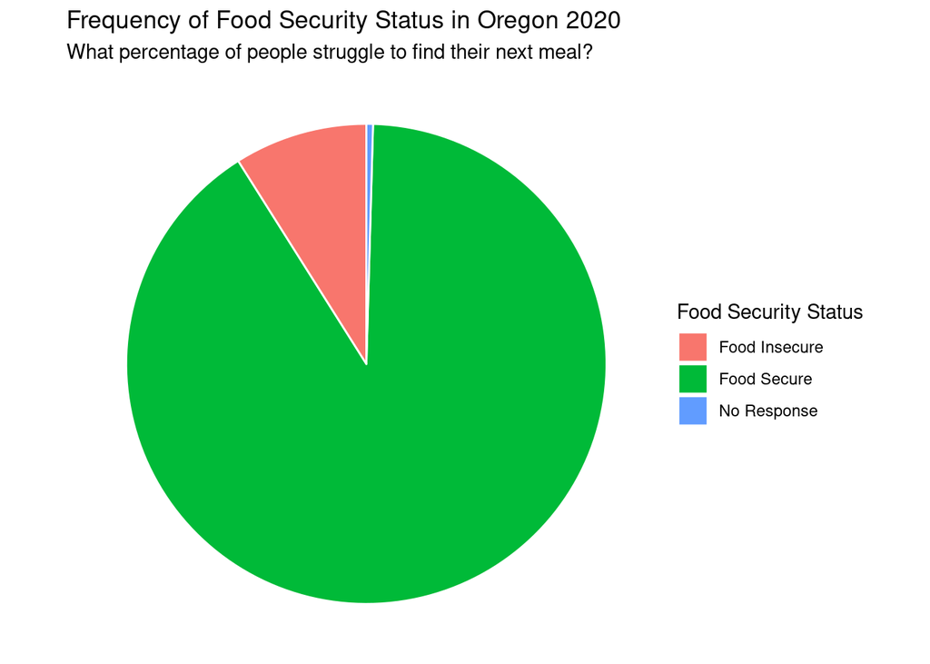

```r
food_insec_rate_12mo <- clean_df %>%
  group_by(food_insec_12mo) %>%
  summarize(cnt = n()) %>%
  mutate(freq = cnt/sum(cnt)) %>%
  arrange(desc(freq))

ggplot(data = food_insec_rate_12mo,
       mapping = aes(x = "",
                     y = freq,
                     fill = food_insec_12mo,
                     label = round(freq, 2))) +
  geom_bar(stat = "identity",
           width = 2,
           color = "white") +
  coord_polar("y", start = 0) +
  theme_void() +
  guides(fill = guide_legend(title = "Food Security Status")) +
  labs(title = "Frequency of Food Security Status in Oregon 2020",
       subtitle = "What percentage of people struggle to find their next meal?")
```

## What types of people are most food insecure?

### How much do food insecure people work?

```r
insec_df <- clean_df %>% # only contains those who are food insecure
  filter(food_insec_12mo %in% c(2, 3))
```